# hw6

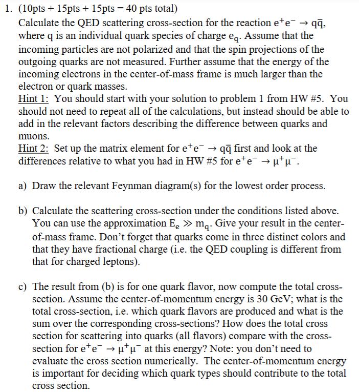

Hopefully, the heavylifting has already been done in HW5, I guess we'll see.

For starters, our Feynman diagram matches pretty well.

(a)

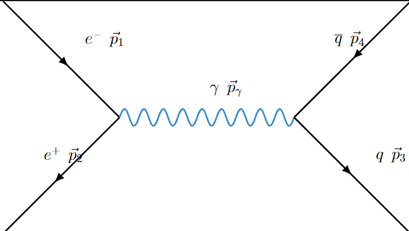

(b) This gives the same momentum relations, the only change is with masses. In HW5, we had

$$ M_{\text{hw5}}= i \int \left[ \bar v_e ig_e \gamma^\mu u_e \right] \frac{-ig_{\mu \nu}}{p_\gamma^2} \left[\bar u_{\Mu} i g_e \gamma^\nu v_\mu\right] \times (2\pi)^4 \delta^4(p_1 + p_2 p_\gamma)(2\pi)^4 \delta^5 (p_\gamma - p_3 - p_4) \frac{d^4 p_\gamma}{(2\pi)^4} \\ M_{\text{hw5}} = -\frac{g_e^2}{(p_1+p_2)^2} \left[ \bar v_e \gamma^\mu u_e \right] \left[ \bar u_\Mu \gamma_\mu v_\Mu \right] $$

The muons and $\Mu$ notation are kinda clashing, so I changed muons to be $\Mu$. So far, no features of muons or electrons have been used, so the ame matrix element can be used for this cross section

$$ M = -\frac{g_e^2 Q_q}{(p_1+p_2)^2} \left[ \bar v_e \gamma^\mu u_e \right] \left[ \bar u_p \gamma_\mu v_p \right] = -\frac{g_e^2 Q_q}{s} \left[ \bar v_e \gamma^\mu u_e \right] \left[ \bar u_p \gamma_\mu v_p \right] $$

Notice that the factor $Q_q$ has been added by the quark vertex, which can be $-1/3$ or $+2/3$ depending on the quark flavor.

In Hw5 we used particle properties to apply Casimir's trick

- $E_e \gg m_\mu$
- sum over e, muon spins

Each quark flavor only has two spin states, and we have the same high energy condition, so this result is also retained

$$ \langle | M | ^2 \rangle = \frac{4 g_e^4 Q_q^2}{s^2} \left(E^2(1-\cos \theta) \right)^2 + \left(E^2 (1+\cos \theta)\right)^2 \\ = g_e^4 Q_q^2 \left( 1 + \cos^2 \theta \right) $$

From this we can find our scattering cross section

$$ \frac{d\sigma}{d\Omega} = \frac{1}{(8\pi)^2} \frac{\langle | M | ^2 \rangle}{(E_1 + E_2)^2} \frac{|p_f |}{|p_i|} \\ = \frac{g_e^4 Q_q^2}{256 \pi^2 E^2} \left(1 + \cos^2 \theta \right) \\ \sigma = \frac{g_e^4 Q_q^2}{48 \pi E^2} $$

(c) We can combine all six quark cross sections to compute the total cross section. With our high energy assumption, the masses of each quark doesn't affect the outcome, only charge.

I know you said numerical evaluation isn't necessary, but I was curious. Using $g_e^2 = 4 \pi \alpha = 0.092$ in natural units

```python
from numpy import pi

q13 = 0.092**2*(1/3)**2/(48*pi*30**2)
q23 = 0.092**2*(2/3)**2/(48*pi*30**2)
print(q13, q23)

qtot = 3*q13 + 3*q23
qtot*0.3894*1e6
```

```
6.929462131326141e-09 2.7717848525304563e-08
```

```
0.04047498830907599
```

Note: At the same energy, scattering to muons is less likely since there is only one type of muon, and the net of all 1/3 and 2/3 factors yields $3(1/3^2 + 2^2/3^2) = 5/3$ total factor, making it 2/3 more likely despite the fractional charge factor

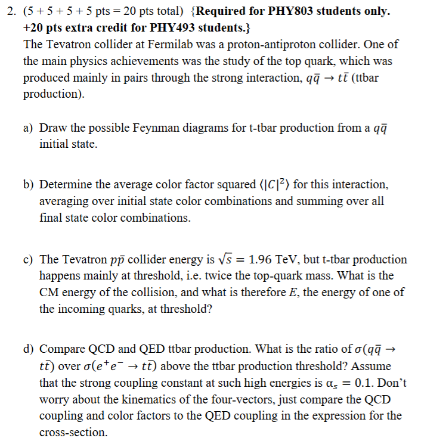

(a) This is s-channel gluon interaction

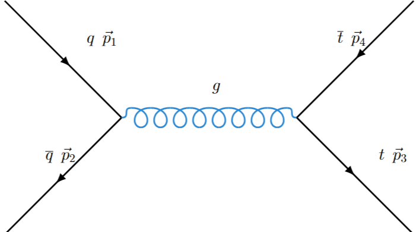

(b) Average over initial state and sum over final state

$$ \langle | C |^2 \rangle = \frac{1}{3^2} \sum_i \sum_f |\mathcal M | ^2 \\ \sum_i \sum_f |\mathcal M | ^2 = 8T_r = 4 \\ \langle | C |^2 \rangle = \frac{4}{9} $$

I'm not sure where $|\mathcal M|^2$ comes from, but I know it's related to the Gell-Mann matricies. I found it on google.

(d) We can keep everything the same, only comparing the coupling constants.

It turns out, these are actually related to the structure constants, since we're at high enough not worrying about kinematics

$$ \frac{\sigma_{\gamma}}{\sigma_{g}} = \frac{\alpha_s \langle | C|^2 \rangle}{\alpha} \alpha = \frac{1}{137} \\ \alpha_s = 0.1 \\ \frac{\sigma_{\gamma}}{\sigma_{g}} = \frac{0.1 * 4/9}{1/137} \approx 6 $$

So it is 6x larger / 6x stronger vs QED, assuming the color factor I found is correct.